# Assignment 5

Zoe Iacovino

10/5/2020

```r
library(tidyverse)
library(ggplot2)
library(ggthemes)
library (ggmosaic)
library(jtools)
library(interactions)
library(knitr)
mfa<- read.csv("2017 ACS Family Assistance Household.csv")%>%
  mutate(FERHb = ifelse(FERH == "No", 0, 1))%>%
  mutate(SNAPb = ifelse(SNAP == "No", 0, 1))%>%
  mutate(FINC = ifelse(FINC == 0, 1, FINC))
#I turned all the households with $0 in annual income to $1 so I could use a long transform.
#mfa is Massachusetts 2017 ACS data aggregated to the household level, and only including houeshold with related children.
```

## Regressions with Interactions

```r
model1 <- lm(KIDS ~ SNAP + FINC + FERH + AGE,
            data = mfa)
model2<- lm(KIDS ~ SNAP + log(FINC) + FERH + AGE,
            data = mfa)
model3<- lm(KIDS ~ SNAP + log(FINC) + FERH + AGE +
              log(FINC):FERH,
            data = mfa)

#Transforming the Age Variable
mfa <- mfa %>%
  mutate(age_bins = case_when(AGE <= 20 ~ "Under 20 Household",
                              AGE> 20 & AGE <= 40  ~ "Younger Household",
                              AGE>40 & AGE < 60 ~ "Middle Aged Household",
                              AGE == 60 ~ "Older Household"))

model4 <- lm(KIDS ~ SNAP + log(FINC) + FERH + age_bins + SNAP:age_bins,
            data = mfa)
```

### Model 1: Initial Linear Regression

```r
summary(model1)
```

```
##
## Call:
## lm(formula = KIDS ~ SNAP + FINC + FERH + AGE, data = mfa)
##
## Residuals:
##     Min      1Q  Median      3Q     Max
## -2.2168 -0.4861 -0.0648  0.3559  8.1759
##
## Coefficients:
##               Estimate Std. Error t value Pr(>|t|)
## (Intercept)  3.004e+00  3.460e-02  86.830   <2e-16 ***
## SNAPYes      2.178e-01  2.608e-02   8.348   <2e-16 ***
## FINC         4.164e-07  1.470e-08  28.329   <2e-16 ***
## FERHYes     -2.549e-01  3.041e-02  -8.382   <2e-16 ***
## AGE         -5.448e-02  1.149e-03 -47.396   <2e-16 ***
## ---
## Signif. codes:  0 '***' 0.001 '**' 0.01 '*' 0.05 '.' 0.1 ' ' 1
##
## Residual standard error: 0.7196 on 7037 degrees of freedom
## Multiple R-squared:  0.298,  Adjusted R-squared:  0.2976
## F-statistic: 746.9 on 4 and 7037 DF,  p-value: < 2.2e-16
```

### Model 2: Log Transformed Income

```r
summary(model2)
```

```
##
## Call:
## lm(formula = KIDS ~ SNAP + log(FINC) + FERH + AGE, data = mfa)
##
## Residuals:
##     Min      1Q  Median      3Q     Max
## -1.7433 -0.4778 -0.0750  0.3528  8.0211
##
## Coefficients:
##              Estimate Std. Error t value Pr(>|t|)
## (Intercept)  1.436876   0.079542   18.06   <2e-16 ***
## SNAPYes      0.302466   0.027711   10.91   <2e-16 ***
## log(FINC)    0.146332   0.005900   24.80   <2e-16 ***
## FERHYes     -0.282686   0.030792   -9.18   <2e-16 ***
## AGE         -0.056483   0.001172  -48.21   <2e-16 ***
## ---
## Signif. codes:  0 '***' 0.001 '**' 0.01 '*' 0.05 '.' 0.1 ' ' 1
##
## Residual standard error: 0.7283 on 7037 degrees of freedom
## Multiple R-squared:  0.2808, Adjusted R-squared:  0.2804
## F-statistic:   687 on 4 and 7037 DF,  p-value: < 2.2e-16
```

### Model 3: Interaction Term of Income and Having a Child in the last year

```r
summary(model3)
```

```
##
## Call:
## lm(formula = KIDS ~ SNAP + log(FINC) + FERH + AGE + log(FINC):FERH,
##     data = mfa)
##
## Residuals:
##     Min      1Q  Median      3Q     Max
## -1.7363 -0.4774 -0.0728  0.3518  8.0180
##
## Coefficients:
##                    Estimate Std. Error t value Pr(>|t|)
## (Intercept)        1.381713   0.081998  16.851  < 2e-16 ***
## SNAPYes            0.299968   0.027713  10.824  < 2e-16 ***
## log(FINC)          0.150897   0.006126  24.631  < 2e-16 ***
## FERHYes            0.360174   0.235849   1.527  0.12677
## AGE               -0.056567   0.001171 -48.288  < 2e-16 ***
## log(FINC):FERHYes -0.051152   0.018606  -2.749  0.00599 **
## ---
## Signif. codes:  0 '***' 0.001 '**' 0.01 '*' 0.05 '.' 0.1 ' ' 1
##
## Residual standard error: 0.728 on 7036 degrees of freedom
## Multiple R-squared:  0.2816, Adjusted R-squared:  0.2811
## F-statistic: 551.6 on 5 and 7036 DF,  p-value: < 2.2e-16
```

As a household’s income doubles, and for families who have had a child in the last year, the number of children in the household is likely to be lower.

### Model 4: Age as a Categorical Variable and interaction of SNAP on Age Groups

```r
summary(model4)
```

```
##
## Call:
## lm(formula = KIDS ~ SNAP + log(FINC) + FERH + age_bins + SNAP:age_bins,
##     data = mfa)
##
## Residuals:
##     Min      1Q  Median      3Q     Max
## -1.8383 -0.6071 -0.0373  0.3403  8.0204
##
## Coefficients: (1 not defined because of singularities)
##                                     Estimate Std. Error t value Pr(>|t|)
## (Intercept)                        -0.766793   0.090636  -8.460  < 2e-16 ***
## SNAPYes                             0.213385   0.112778   1.892   0.0585 .
## log(FINC)                           0.142962   0.006245  22.893  < 2e-16 ***
## FERHYes                            -0.208162   0.032602  -6.385 1.82e-10 ***
## age_binsOlder Household            -0.277368   0.768866  -0.361   0.7183
## age_binsUnder 20 Household          1.340024   0.047294  28.334  < 2e-16 ***
## age_binsYounger Household           0.596575   0.041069  14.526  < 2e-16 ***
## SNAPYes:age_binsOlder Household           NA         NA      NA       NA
## SNAPYes:age_binsUnder 20 Household  0.256059   0.122632   2.088   0.0368 *
## SNAPYes:age_binsYounger Household   0.034636   0.117880   0.294   0.7689
## ---
## Signif. codes:  0 '***' 0.001 '**' 0.01 '*' 0.05 '.' 0.1 ' ' 1
##
## Residual standard error: 0.7678 on 7033 degrees of freedom
## Multiple R-squared:  0.2012, Adjusted R-squared:  0.2003
## F-statistic: 221.4 on 8 and 7033 DF,  p-value: < 2.2e-16
```

The largest effect on the number of children in the household shown in any of the models is the average age of the household being under 20. This makes sense, as more children in the household will drive the average age lower. The interaction of SNAP on the average age groups is not measurable or statistically significant except for the under 20 household.

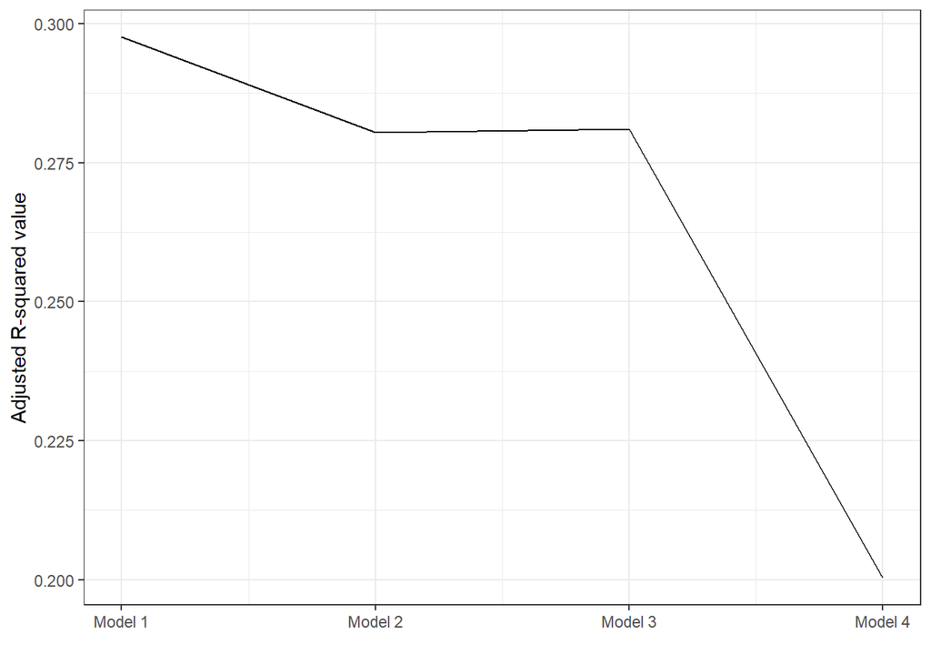

```r
ModelFit <- tibble(model = c(1, 2, 3, 4),
                   R_square = c(summary(model1)$adj.r.squared,
                                summary(model2)$adj.r.squared,
                                summary(model3)$adj.r.squared,
                                summary(model4)$adj.r.squared))

ggplot(ModelFit, aes(x = model, y = R_square)) +
  geom_line() +
  scale_x_continuous(name = "",
                   breaks = breaks <- seq(1, 4, by = 1),
                   labels = paste("Model", breaks)) +
  scale_y_continuous(name = "Adjusted R-squared value") +
  theme_bw()
```

This shows that the linear regression with no interactions is actually the best fit.

```r
coeff_names <- c("Annual Household income\n(log-transformed)" = "log(FINC)",
                 "SNAP Recipient\n(compared to non-SNAP Recipient)" = "SNAPYes",
                 "Average Household Age" = "AGE",
                 "Had a Baby in Last Year" = "FERHYes",
                 "Interaction: Household Income\n(log-transformed)\nand Baby in Last Year" =  "log(FINC):FERHYes")




export_summs(model1, model3,
             error_format = "(p = {p.value})",
             error_pos = "same",
             model.names = c("Initial model", "Interactions model"),
             coefs = coeff_names)
```

|  | Initial model | Interactions model |
| --- | --- | --- |
| Annual Household income (log-transformed) |  | 0.15 *** (p = 0.00) |
| SNAP Recipient (compared to non-SNAP Recipient) | 0.22 *** (p = 0.00) | 0.30 *** (p = 0.00) |
| Average Household Age | -0.05 *** (p = 0.00) | -0.06 *** (p = 0.00) |
| Had a Baby in Last Year | -0.25 *** (p = 0.00) | 0.36 (p = 0.13) |
| Interaction: Household Income (log-transformed) and Baby in Last Year |  | -0.05 ** (p = 0.01) |
| N | 7042 | 7042 |
| R2 | 0.30 | 0.28 |
| *** p < 0.001; ** p < 0.01; * p < 0.05. |  |  |

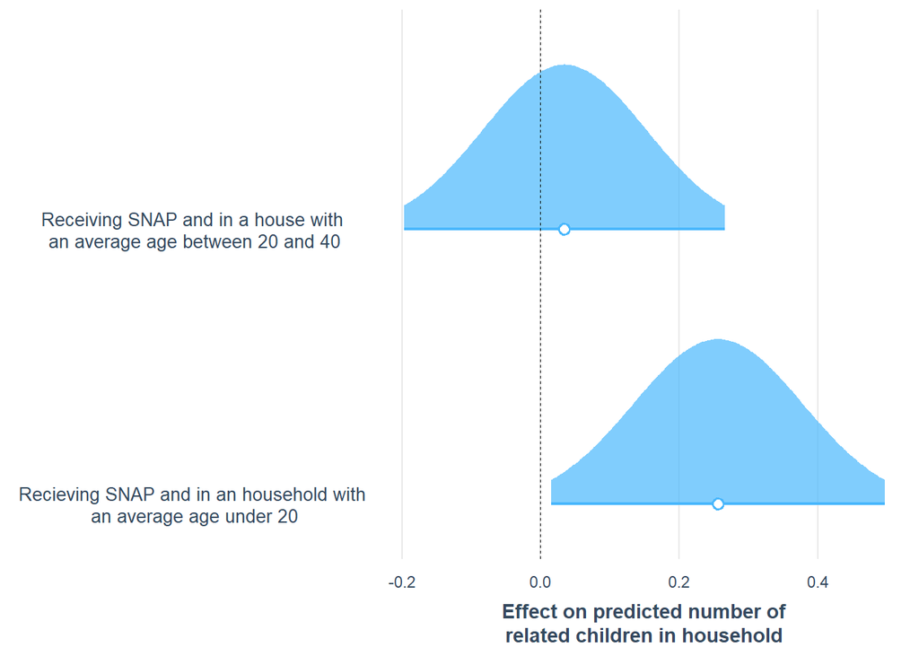

```r
coeff_desc <- c(
  "Recieving Snap and in a house with\n an average age over 60" = "SNAPYes:age_binsOlder Household",
  "Recieving SNAP and in an household with\n an average age under 20" =  "SNAPYes:age_binsUnder 20 Household",
  "Receiving SNAP and in a house with\n an average age between 20 and 40" = "SNAPYes:age_binsYounger Household",
  "Receiving SNAP and in a houes with\n an average age between 40 and 60" = "SNAPYes:age_binsMiddle Aged Household")

plot_coefs(model4,
           coefs = coeff_desc,
           plot.distributions = TRUE,
           rescale.distributions = TRUE) +
  scale_x_continuous(name = "Effect on predicted number of\nrelated children in household")
```

```
## Using data mfa from global environment. This could cause incorrect results
## if mfa has been altered since the model was fit. You can manually provide
## the data to the "data =" argument.
```

[output not shown]

[output not shown]

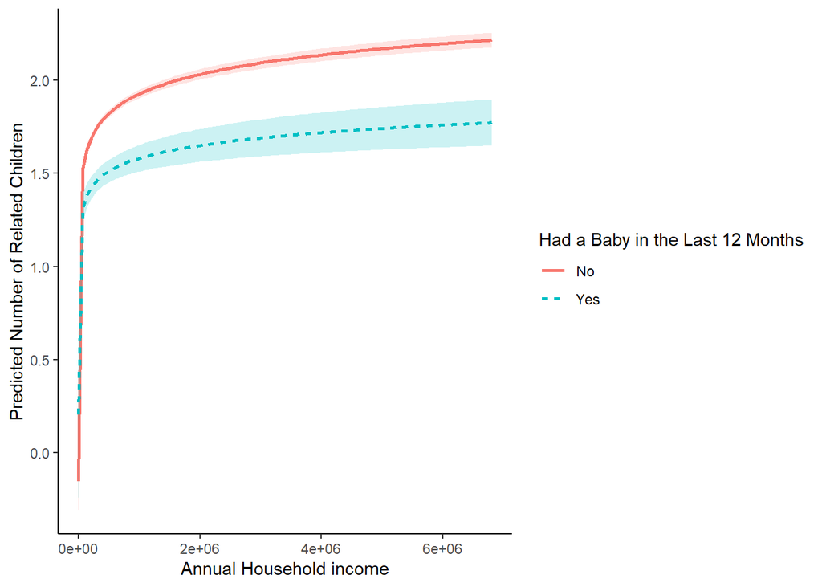

```r
interact_plot(model3, pred = FINC, modx = FERH, interval = TRUE)+
  scale_x_continuous(name = "Annual Household income") +
  scale_y_continuous(name = "Predicted Number of Related Children")+
  scale_color_discrete(name = "Had a Baby in the Last 12 Months") +
  scale_linetype_discrete(name = "Had a Baby in the Last 12 Months") +
  scale_fill_discrete(name = "Had a Baby in the Last 12 Months")+
  theme_classic()
```

As income increases, it is more likely that households that did not have a child in the last 12 months will have more children. This could make sense that households with higher incomes are not having more children, and households who are maybe just starting their families are also in earlier stages of careers and earning less.

## Logistic Regression

```r
model_log <- glm(FERHb ~ SNAPb + log(FINC) + KIDS + log(FINC):KIDS,
            data = mfa,
            family = binomial())

summary(model_log)
```

```
##
## Call:
## glm(formula = FERHb ~ SNAPb + log(FINC) + KIDS + log(FINC):KIDS,
##     family = binomial(), data = mfa)
##
## Deviance Residuals:
##     Min       1Q   Median       3Q      Max
## -0.8851  -0.4389  -0.4336  -0.4164   2.2809
##
## Coefficients:
##                Estimate Std. Error z value Pr(>|z|)
## (Intercept)    -3.19860    0.71140  -4.496 6.92e-06 ***
## SNAPb           0.33559    0.12097   2.774  0.00553 **
## log(FINC)       0.05499    0.05645   0.974  0.32993
## KIDS            0.53202    0.31377   1.696  0.08997 .
## log(FINC):KIDS -0.03405    0.02469  -1.379  0.16783
## ---
## Signif. codes:  0 '***' 0.001 '**' 0.01 '*' 0.05 '.' 0.1 ' ' 1
##
## (Dispersion parameter for binomial family taken to be 1)
##
##     Null deviance: 4367.5  on 7041  degrees of freedom
## Residual deviance: 4348.8  on 7037  degrees of freedom
## AIC: 4358.8
##
## Number of Fisher Scoring iterations: 5
```

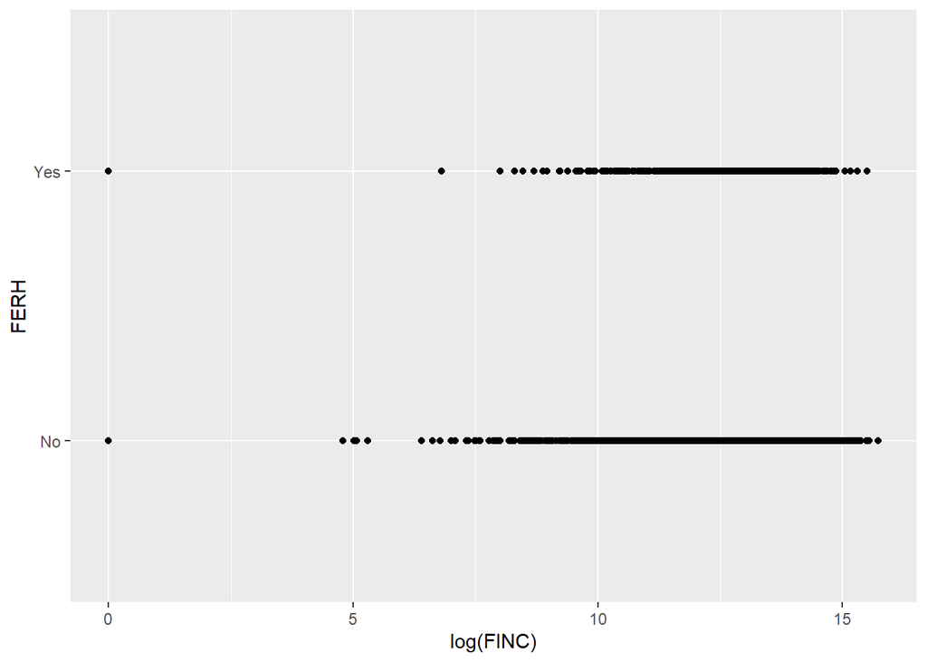

```r
ggplot(mfa, aes(x=log(FINC), y=FERH)) + geom_point() +
  stat_smooth(method="glm", method.args=list(family="binomial"), se=FALSE)
```

These results are not really statistically significant. Sad!